# Multilevel and Longitudinal

## Data wide -> long

Number of obs. 76 -> 152 Number of variables 6 -> 6 j variable (2 values) -> time xij variables: weight0 weight1 -> weight —————————————————————————–

Performing EM optimization:

Performing gradient-based optimization:

Iteration 0: log restricted-likelihood = -441.21923  
Iteration 1: log restricted-likelihood = -441.21391  
Iteration 2: log restricted-likelihood = -441.21288  
Iteration 3: log restricted-likelihood = -441.21287

Computing standard errors:

Mixed-effects REML regression Number of obs = 152 Group variable: person Number of groups = 76

```
                                            Obs per group:
                                                          min =          2
                                                          avg =        2.0
                                                          max =          2

                                            Wald chi2(1)      =     188.47
```

Log restricted-likelihood = -441.21287 Prob > chi2 = 0.0000

| weight \| Coef. Std. Err. z P>\|z\| [95% Conf. Interval] |
| --- |
| ————-+—————————————————————- |
| time \| -3.946053 .2874357 -13.73 0.000 -4.509416 -3.382689 |
| _cons \| 72.28947 .9147546 79.03 0.000 70.49659 74.08236 |

Random-effects Parameters | Estimate Std. Err. [95% Conf. Interval] —————————–+———————————————— person: Independent | sd(time) | 1.162477 1.971757 .0418411 32.29724 sd(_cons) | 7.818639 .6549673 6.634772 9.213747 —————————–+———————————————— sd(Residual) | 1.569667 .7404594 .6226877 3.956809

LR test vs. linear model: chi2(2) = 176.38 Prob > chi2 = 0.0000

Note: LR test is conservative and provided only for reference. ```

# Complete, Partial and No pooling

## Complete Pooling

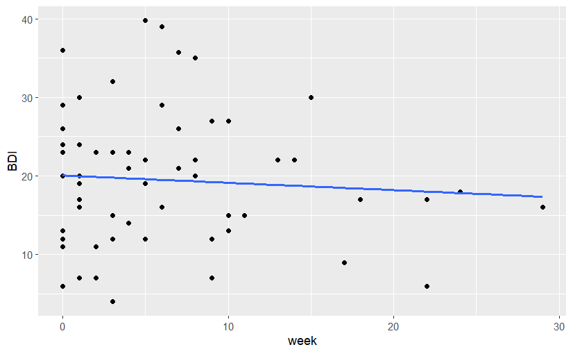

## No pooling

**Plot**

depression.long %>% filter(ID %in% sample_ids) %>% ggplot(aes(x = week, y = BDI, colour = ID)) + geom_point() + geom_path()

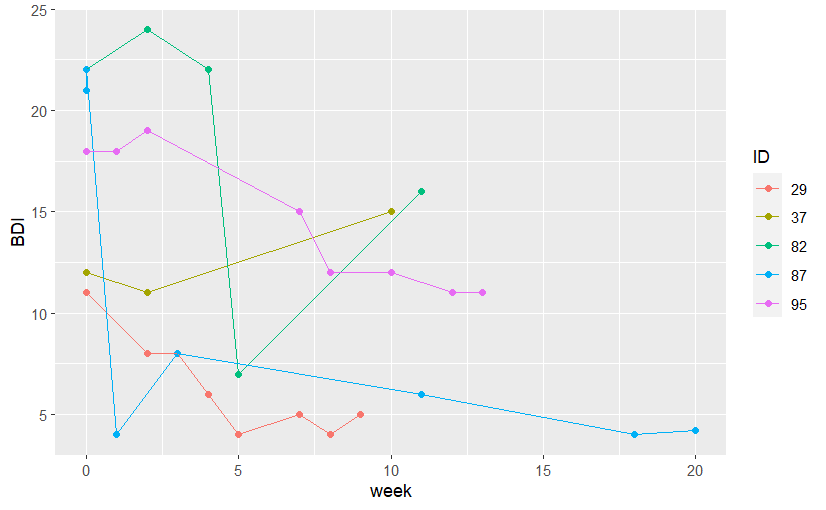

sample_ids <- sample(unique(depression.long$ID), 5)

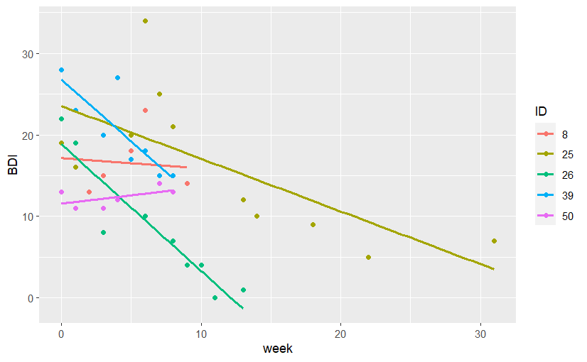

# Two-Level Empty Model

1. $Y_{ij} = \beta_{0j} + e_{ij}$ 2. i = individual 3. j = level (i.e., group) 4. beta_0j = mean Y for group j 5. error_ij = error term for each individual 6. $\beta_{0j} = \beta_0 + u_{0j}$ 7. beta_0 is the overall mean (i.e., the estimated mean of the whole sample) 8. u_oj is the error term for the group 9. Combining both equations we get: 10. $Y_{ij} = \beta_0 + u_{0j} + e_{ij}$ 11. Meaning: *dependent_var =* *total_mean + error_term_level_2 + error_term_level_1*

``` Linear mixed model fit by REML. t-tests use Satterthwaite’s method [‘lmerModLmerTest’] Formula: BDI ~ (1 | ID) Data: depression.long

REML criterion at convergence: 3656.6

Scaled residuals: Min 1Q Median 3Q Max -2.3139 -0.6395 -0.1071 0.5824 3.2782

Random effects: Groups Name Variance Std.Dev. ID (Intercept) 58.48 7.647 Residual 29.55 5.436 Number of obs: 553, groups: ID, 85

Fixed effects: Estimate Std. Error df t value Pr(>|t|) (Intercept) 16.1677 0.8674 83.2362 18.64 <2e-16 ***

Signif. codes: 0 ‘**’ 0.001 ‘**’ 0.01 ‘’ 0.05 ‘.’ 0.1 ‘ ’ 1

```
**STATA**

1.  In STATA we use the mixed command, where the syntax is
2.  `mixed depvar fe_equation [|| re_equation] [|| re_equation …] [, options]`
3.  *fe_equation* : `[indepvars] [if] [in] [weight] [, fe_options]`
4.  *re_equation* is either: `levelvar: [varlist] [, re_options]`
5.  or: `levelvar: R.varname [, re_options]`
6.  *levelvar* is a variable identifying the group structure for the random effects at that level or is \_all representing one group comprising all observations.
7.  options, : we can use *mle* (or reml) to specify maximum likelyhood estimation and *variance* or *stddev* (among other options) to specify what to report
8.  If we want the same result as in R we must either specify (REML = FALSE in R, and , mle in STATA) or (REML = TRUE in R, and ,reml in STATA)
```

Performing EM optimization:

Performing gradient-based optimization:

Iteration 0: log restricted-likelihood = -1828.287  
Iteration 1: log restricted-likelihood = -1828.287

Computing standard errors:

Mixed-effects REML regression Number of obs = 553 Group variable: ID Number of groups = 85

```
                                            Obs per group:
                                                          min =          2
                                                          avg =        6.5
                                                          max =         11

                                            Wald chi2(0)      =          .
```

Log restricted-likelihood = -1828.287 Prob > chi2 = .

| BDI \| Coef. Std. Err. z P>\|z\| [95% Conf. Interval] |
| --- |
| ————-+—————————————————————- |
| _cons \| 16.16772 .8673879 18.64 0.000 14.46767 17.86777 |

[output not shown]

Signif. codes: 0 ‘**’ 0.001 ‘**’ 0.01 ‘’ 0.05 ‘.’ 0.1 ‘ ’ 1

Correlation of Fixed Effects: (Intr) week -0.250

running C: > le.do . mixed BDI week || ID: , reml stddev

Performing EM optimization:

Performing gradient-based optimization:

Iteration 0: log restricted-likelihood = -1752.0152  
Iteration 1: log restricted-likelihood = -1752.0152

Computing standard errors:

Mixed-effects REML regression Number of obs = 553 Group variable: ID Number of groups = 85

```
                                            Obs per group:
                                                          min =          2
                                                          avg =        6.5
                                                          max =         11

                                            Wald chi2(1)      =     183.67
```

Log restricted-likelihood = -1752.0152 Prob > chi2 = 0.0000

| BDI \| Coef. Std. Err. z P>\|z\| [95% Conf. Interval] |
| --- |
| ————-+—————————————————————- |
| week \| -.5781395 .0426597 -13.55 0.000 -.6617509 -.494528 |
| _cons \| 19.09525 .8577768 22.26 0.000 17.41403 20.77646 |

[output not shown]

```
     BDI |      Coef.   Std. Err.      z    P>|z|     [95% Conf. Interval]
```

————-+—————————————————————- week | -.5781395 .0426597 -13.55 0.000 -.6617509 -.494528 _cons | 19.09525 .8577768 22.26 0.000 17.41403 20.77646 ——————————————————————————

Random-effects Parameters | Estimate Std. Err. [95% Conf. Interval] —————————–+———————————————— ID: Identity | sd(_cons) | 7.391516 .6123993 6.283623 8.694748 —————————–+———————————————— sd(Residual) | 4.637204 .1517305 4.349152 4.944333

LR test vs. linear model: chibar2(01) = 453.72 Prob >= chibar2 = 0.0000 ```

### Visualizing the model

`[1] \32\ \28\ \82\ \61\ \11\`

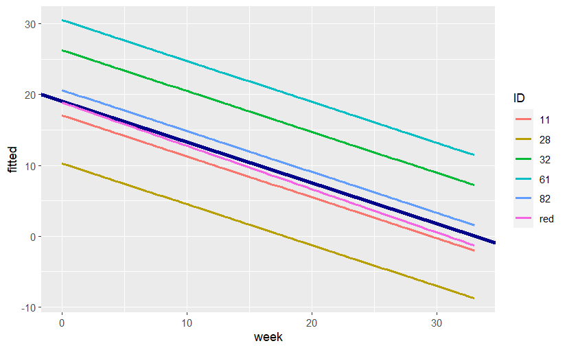

**STATA**

1. I havent found a(n easy) way of visualizing this in STATA

## Random Coefficents Model

``` Linear mixed model fit by REML. t-tests use Satterthwaite’s method [‘lmerModLmerTest’] Formula: BDI ~ week + (1 + week | ID) Data: depression.long

REML criterion at convergence: 3405.8

Scaled residuals: Min 1Q Median 3Q Max -2.7948 -0.5220 -0.0360 0.4724 3.8392

Random effects: Groups Name Variance Std.Dev. Corr ID (Intercept) 47.4943 6.8916 week 0.3707 0.6089 -0.03 Residual 14.5184 3.8103 Number of obs: 553, groups: ID, 85

Fixed effects: Estimate Std. Error df t value Pr(>|t|) (Intercept) 19.72818 0.79607 82.13025 24.782 < 2e-16 *week -0.75946 0.08598 58.26743 -8.833 2.41e-12*

Signif. codes: 0 ‘**’ 0.001 ‘**’ 0.01 ‘’ 0.05 ‘.’ 0.1 ‘ ’ 1